# Day2, Session 3: Linear Mixed Effects Regression - Workflow

Dusica Filipovic Durdevic

2026-09-15

## To start, let’s load the packages we need

```r
library(rms)
library(lme4)
library(languageR)
library(multcomp)
library(emmeans) #library(lsmeans)
library(multcompView)
library(pbkrtest)
library(lmerTest)
library(gbm)
library(randomForest)
library(party) # zameniti sa partykit ili ranger
library(MASS)
library(car)
library(mgcv)
library(itsadug)
library(methods)
library(effects)
library(RePsychLing)
library(knitr)
library(broom)
library(parameters)
library(ggplot2)
library(see)
```

## Then let’s check what our working directory is

```r
getwd()
```

```
## [1] "C:/Eowyn/Dokumenti/Obuke/!MOJE_2026"
```

- if it isn’t the one we want, we set it to be so (it’s most convenient for it to be the one containing the data file)

```r
setwd("C:/Eowyn/Dokumenti/Obuke/!MOJE_2026")
```

- let’s check whether we succeeded

```r
getwd()
```

```
## [1] "C:/Eowyn/Dokumenti/Obuke/!MOJE_2026"
```

## Then we load and look at the data

```r
dat=read.table("FilipovicDurdevic.Kostic.SerbianPolysemy_short.txt",sep="\t",TRUE)

dim(dat)
```

```
## [1] 4650   17
```

```r
colnames(dat)
```

```
##  [1] "Participant"  "Trial_number" "Trial_order"  "Error_code"   "RT"
##  [6] "Word"         "len"          "fam"          "conc"         "freko"
## [11] "ort"          "N"            "H"            "Hrel"         "T"
## [16] "pp1"          "pp1_pp2"
```

```r
head(dat)
```

```
##     Participant Trial_number Trial_order Error_code  RT   Word len  fam conc
## 1 Participant_1            1          42          1 641   SILA   4 6.53 2.26
## 2 Participant_1            2         199          1 661  KLJU^   5 6.83 6.57
## 3 Participant_1            3          48          1 771  STOPA   5 5.94 4.52
## 4 Participant_1            4         197          1 681  POJAS   5 6.35 5.86
## 5 Participant_1            5          43          1 580 STEPEN   6 5.94 2.35
## 6 Participant_1            6         291          1 540  JEZIK   5 6.88 5.24
##   freko ort  N        H      Hrel         T       pp1    pp1_pp2
## 1   365  13 23 3.986627 0.8813027 0.1186973 0.1571429 0.04285714
## 2   106   1 11 2.993384 0.8652820 0.1347180 0.2608696 0.10144928
## 3   379   6  8 2.615237 0.8717458 0.1282542 0.2641509 0.01886793
## 4   111   2 16 3.521572 0.8803931 0.1196069 0.1875000 0.03125000
## 5   106   1 11 2.861359 0.8271183 0.1728817 0.2407407 0.00000000
## 6   537   2 14 3.094742 0.8128325 0.1871675 0.2500000 0.03571429
```

```r
str(dat)
```

```
## 'data.frame':    4650 obs. of  17 variables:
##  $ Participant : chr  "Participant_1" "Participant_1" "Participant_1" "Participant_1" ...
##  $ Trial_number: int  1 2 3 4 5 6 7 8 9 10 ...
##  $ Trial_order : int  42 199 48 197 43 291 84 201 122 234 ...
##  $ Error_code  : int  1 1 1 1 1 1 1 1 1 1 ...
##  $ RT          : int  641 661 771 681 580 540 611 901 781 571 ...
##  $ Word        : chr  "SILA" "KLJU^" "STOPA" "POJAS" ...
##  $ len         : int  4 5 5 5 6 5 5 6 5 5 ...
##  $ fam         : num  6.53 6.83 5.94 6.35 5.94 6.88 6.71 6.74 6.31 6.74 ...
##  $ conc        : num  2.26 6.57 4.52 5.86 2.35 5.24 5.7 4.81 6.43 6.24 ...
##  $ freko       : int  365 106 379 111 106 537 274 226 111 719 ...
##  $ ort         : int  13 1 6 2 1 2 0 5 1 2 ...
##  $ N           : int  23 11 8 16 11 14 14 34 11 18 ...
##  $ H           : num  3.99 2.99 2.62 3.52 2.86 ...
##  $ Hrel        : num  0.881 0.865 0.872 0.88 0.827 ...
##  $ T           : num  0.119 0.135 0.128 0.12 0.173 ...
##  $ pp1         : num  0.157 0.261 0.264 0.188 0.241 ...
##  $ pp1_pp2     : num  0.0429 0.1014 0.0189 0.0312 0 ...
```

## I like to immediately put whatever will be my categorical predictor into the right format

```r
dat$Participant = as.factor(dat$Participant)
dat$Word = as.factor(dat$Word)
```

- let’s look again

```r
str(dat)
```

```
## 'data.frame':    4650 obs. of  17 variables:
##  $ Participant : Factor w/ 31 levels "Participant_1",..: 1 1 1 1 1 1 1 1 1 1 ...
##  $ Trial_number: int  1 2 3 4 5 6 7 8 9 10 ...
##  $ Trial_order : int  42 199 48 197 43 291 84 201 122 234 ...
##  $ Error_code  : int  1 1 1 1 1 1 1 1 1 1 ...
##  $ RT          : int  641 661 771 681 580 540 611 901 781 571 ...
##  $ Word        : Factor w/ 150 levels "PE\x8aAK","PO\x8aTA",..: 111 40 122 87 121 37 100 55 51 137 ...
##  $ len         : int  4 5 5 5 6 5 5 6 5 5 ...
##  $ fam         : num  6.53 6.83 5.94 6.35 5.94 6.88 6.71 6.74 6.31 6.74 ...
##  $ conc        : num  2.26 6.57 4.52 5.86 2.35 5.24 5.7 4.81 6.43 6.24 ...
##  $ freko       : int  365 106 379 111 106 537 274 226 111 719 ...
##  $ ort         : int  13 1 6 2 1 2 0 5 1 2 ...
##  $ N           : int  23 11 8 16 11 14 14 34 11 18 ...
##  $ H           : num  3.99 2.99 2.62 3.52 2.86 ...
##  $ Hrel        : num  0.881 0.865 0.872 0.88 0.827 ...
##  $ T           : num  0.119 0.135 0.128 0.12 0.173 ...
##  $ pp1         : num  0.157 0.261 0.264 0.188 0.241 ...
##  $ pp1_pp2     : num  0.0429 0.1014 0.0189 0.0312 0 ...
```

## Let’s check whether there are Participants who made too many errors

```r
sort(tapply(dat$Error_code, dat$Participant, sum)/150)
```

```
## Participant_57 Participant_13 Participant_17  Participant_6 Participant_20
##      0.7333333      0.8466667      0.8533333      0.9266667      0.9333333
## Participant_21 Participant_16 Participant_19 Participant_22 Participant_24
##      0.9466667      0.9533333      0.9533333      0.9533333      0.9533333
## Participant_26 Participant_18  Participant_8 Participant_11 Participant_27
##      0.9533333      0.9600000      0.9600000      0.9666667      0.9666667
##  Participant_3 Participant_30  Participant_5  Participant_9 Participant_12
##      0.9666667      0.9666667      0.9666667      0.9666667      0.9733333
## Participant_28  Participant_1 Participant_10  Participant_2 Participant_23
##      0.9733333      0.9800000      0.9800000      0.9800000      0.9800000
##  Participant_4  Participant_7 Participant_15 Participant_25 Participant_14
##      0.9800000      0.9800000      0.9866667      0.9866667      0.9933333
## Participant_29
##      0.9933333
```

## based on that, let’s exclude one Participant

```r
dat=dat[dat$Participant!="Participant_57",]

dim(dat)
```

```
## [1] 4500   17
```

## Let’s check whether there are words with a large number of errors

```r
sort(tapply(dat$Error_code, dat$Word, sum)/30)
```

```
##     PISAK    PATENT     SFERA     REBRO     BERBA  PE\x8aAK     MEHUR     GLUMA
## 0.5000000 0.7333333 0.7333333 0.7666667 0.8000000 0.8333333 0.8333333 0.8666667
##    LINIJA     POLET      TEZA     BRADA    CIKLUS     GRA?A     IZLET     KANAL
## 0.8666667 0.8666667 0.8666667 0.9000000 0.9000000 0.9000000 0.9000000 0.9000000
##    KOMORA      KURS     OKLOP      PLOD    PROFIL      SLOJ    BALKON     CREVO
## 0.9000000 0.9000000 0.9000000 0.9000000 0.9000000 0.9000000 0.9333333 0.9333333
##    DVOJKA     GRUPA      GUMA      KLUB     KOREN     LANAC      LOZA      MOST
## 0.9333333 0.9333333 0.9333333 0.9333333 0.9333333 0.9333333 0.9333333 0.9333333
##      OBIM     ORGAN     PESAK      SKOK      STAV     STRUK     TEZGA     VRE]A
## 0.9333333 0.9333333 0.9333333 0.9333333 0.9333333 0.9333333 0.9333333 0.9333333
##     ZGLOB  PO\x8aTA      ?AVO      ^VOR     ALBUM     BALON     GRUDI     IGRA^
## 0.9333333 0.9666667 0.9666667 0.9666667 0.9666667 0.9666667 0.9666667 0.9666667
##     IZBOR     IZVOR     KAPAK     KLJU^     KLJUN     KLUPA     KOLA^    KORICA
## 0.9666667 0.9666667 0.9666667 0.9666667 0.9666667 0.9666667 0.9666667 0.9666667
##     KRUNA     MARKA      MASA     MINUT     MOTIV    OBLAST     OBLIK    OBRADA
## 0.9666667 0.9666667 0.9666667 0.9666667 0.9666667 0.9666667 0.9666667 0.9666667
##     OBRU^    PLATNO     PLO^A    POJAVA    POKRET    POSKOK     POTEZ     PRUGA
## 0.9666667 0.9666667 0.9666667 0.9666667 0.9666667 0.9666667 0.9666667 0.9666667
##    RADNJA     SCENA    SKAKA^     STENA    STEPEN     TEKST    TERMIN     TRAKA
## 0.9666667 0.9666667 0.9666667 0.9666667 0.9666667 0.9666667 0.9666667 0.9666667
##      UKUS     USLOV      VEZA  \x8aKOLA    ]ELIJA    ^LANAK      BLOK      BOKS
## 0.9666667 0.9666667 0.9666667 1.0000000 1.0000000 1.0000000 1.0000000 1.0000000
##   \x8eICA    CENTAR     DINAR      DISK    DOKTOR     DUGME    FIGURA     FORMA
## 1.0000000 1.0000000 1.0000000 1.0000000 1.0000000 1.0000000 1.0000000 1.0000000
##     GOVOR     IZRAZ     JEZIK     KOMAD     KORAK      KRUG     KRZNO      LIST
## 1.0000000 1.0000000 1.0000000 1.0000000 1.0000000 1.0000000 1.0000000 1.0000000
##     LOPTA    MATICA      MERA     METAR     MIRIS     MODEL     MOMAK     OCENA
## 1.0000000 1.0000000 1.0000000 1.0000000 1.0000000 1.0000000 1.0000000 1.0000000
##    OSNOVA     PISMO     POJAS     POSAO     POZIV    PRAVAC    PRENOS    PRILOG
## 1.0000000 1.0000000 1.0000000 1.0000000 1.0000000 1.0000000 1.0000000 1.0000000
##     RA^UN     SALON    SAMICA    SASTAV     SAVET    SERVIS    SIGNAL      SILA
## 1.0000000 1.0000000 1.0000000 1.0000000 1.0000000 1.0000000 1.0000000 1.0000000
##    SISTEM      SLUH      SMER    SNIMAK     STOPA    STRUJA     TA^KA     TABLA
## 1.0000000 1.0000000 1.0000000 1.0000000 1.0000000 1.0000000 1.0000000 1.0000000
##     TALAS      UGAO     USPON     VATRA     VENAC    VISINA      VRAT     ZAKON
## 1.0000000 1.0000000 1.0000000 1.0000000 1.0000000 1.0000000 1.0000000 1.0000000
##      ZNAK      ZRNO     ZVONO   KO\x8eA PRA\x8aAK  MRE\x8eA
## 1.0000000 1.0000000 1.0000000 1.0000000 1.0000000 1.0000000
```

## based on that, let’s exclude a few words

```r
dat=dat[dat$Word!="PISAK",]
dat=dat[dat$Word!="PATENT",]
dat=dat[dat$Word!="SFERA",]
dim(dat)
```

```
## [1] 4410   17
```

- we excluded about 2% of the data

```r
(4500 - 4410)/4500
```

```
## [1] 0.02
```

## Let’s keep only correct responses

```r
dat=dat[dat$Error_code == "1",]
dim(dat)
```

```
## [1] 4258   17
```

- in total we excluded about 5% of the data

```r
(4500 - 4258)/4500
```

```
## [1] 0.05377778
```

## Visual inspection of the RT distribution

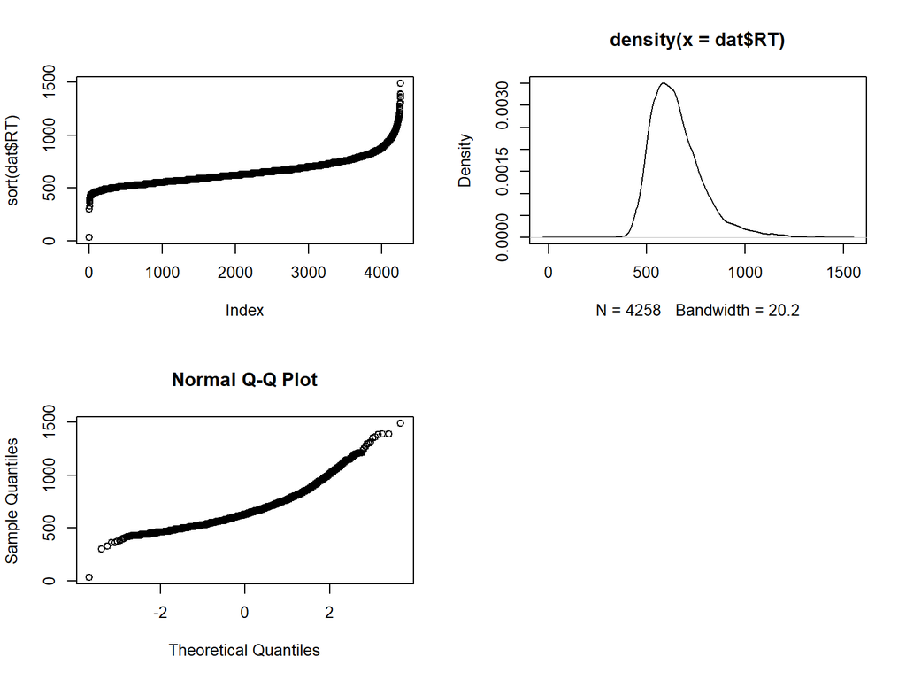

```r
par(mfrow=c(2,2))
plot(sort(dat$RT))
plot(density(dat$RT))
qqnorm(dat$RT)
par(mfrow=c(1,1))
```

```r
dat=dat[dat$RT>299,]
dim(dat)
```

```
## [1] 4257   17
```

## Let’s check which transformation of RT is recommended

```r
powerTransform(dat$RT)
```

```
## Estimated transformation parameter
##     dat$RT
## -0.9260321
```

## Let’s apply the inverse transformation

```r
dat$RT=-1000/dat$RT
```

## Let’s look at how the new RT is distributed

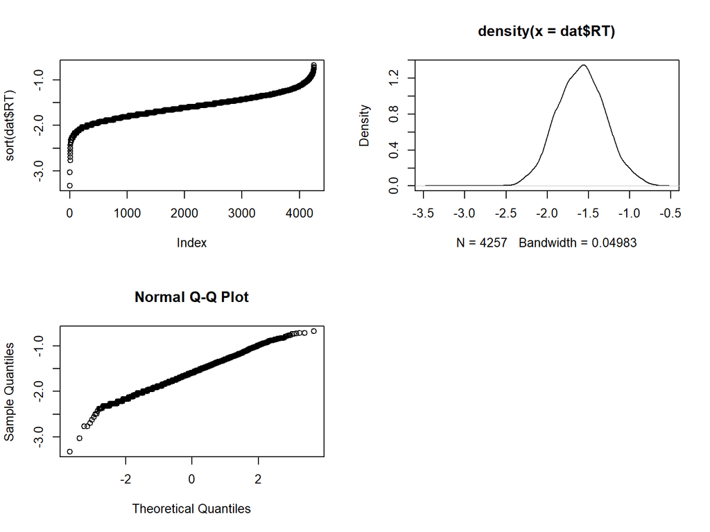

```r
par(mfrow=c(2,2))
plot(sort(dat$RT))
plot(density(dat$RT))
qqnorm(dat$RT)
par(mfrow=c(1,1))
```

## We can also test for normality

```r
shapiro.test(dat$RT)
```

```
##
##  Shapiro-Wilk normality test
##
## data:  dat$RT
## W = 0.99676, p-value = 5.912e-08
```

```r
ks.test(jitter(dat$RT),"pnorm",mean(dat$RT),sd(dat$RT))
```

```
##
##  Asymptotic one-sample Kolmogorov-Smirnov test
##
## data:  jitter(dat$RT)
## D = 0.022347, p-value = 0.02848
## alternative hypothesis: two-sided
```

## Let’s define right away the inverse function, which we’ll need for a nice y-axis when plotting RT

```r
trans <- function(x){
  rezultat <- -1000/x
  return(rezultat)
}
```

## Since the main variable in this analysis is H

- we’ll use it to illustrate how the trans function is used
- at the same time, here we can already see that this effect might be non-linear

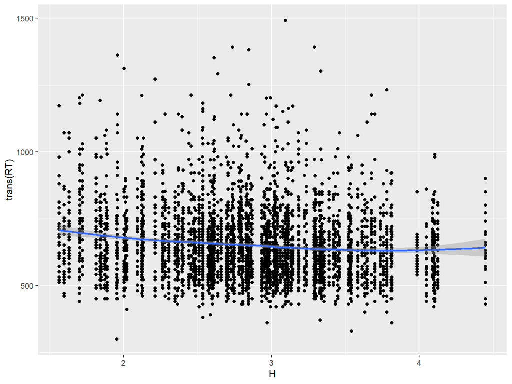

```r
ggplot(dat, aes(x=H, y=trans(RT))) +
  geom_point() +
  geom_smooth(method = "loess", se = TRUE)
```

## Let’s log-transform frequency

```r
dat$freko=log(dat$freko)
```

## Let’s examine collinearity among the predictors

```r
collin.fnc(dat[,c("len", "ort", "freko", "fam","conc", "H" )])$cnumber
```

```
## [1] 63.77733
```

- The kappa coefficient is huge.
- 0-6 low
- 15-29 moderate
- > 29 high

## Since the Kappa coefficient is catastrophically large, we’ll need to resolve the collinearity problem. First, let’s look at what the relationship between the variables looks like

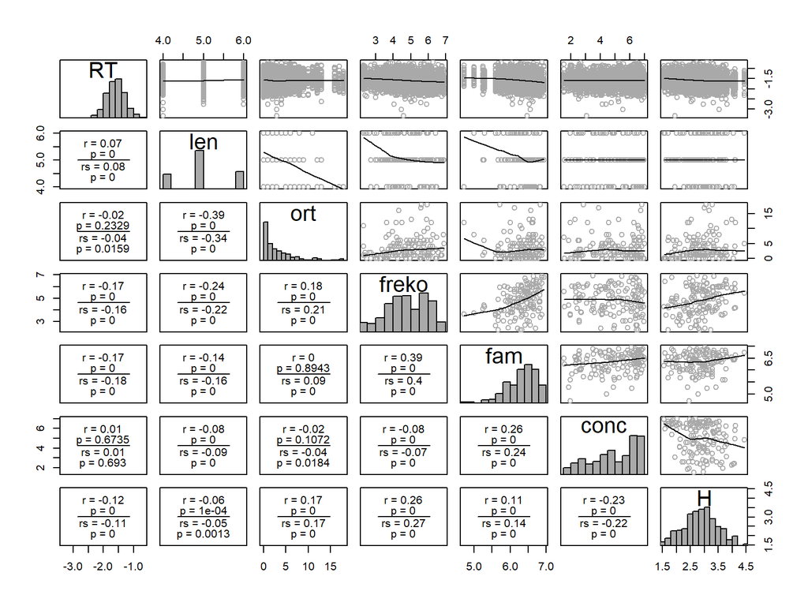

```r
pairscor.fnc(dat[,c("RT", "len", "ort", "freko", "fam","conc", "H")], hist=TRUE, smooth=TRUE, cex.point=1, col.points="darkgrey")
```

## There are several strategies for resolving collinearity

- one option is to choose the most influential predictors
- or to choose one predictor from each group of related predictors
- or to combine several related predictors into a new score
- or to run a principal component analysis
- to start, let’s see how the predictors rank in terms of their influence on the dependent variable

## randomForest

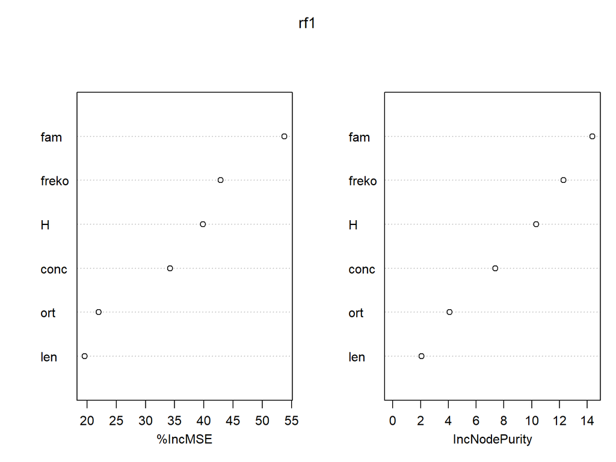

```r
rf1 <- randomForest(RT ~ ., data = dat[,c("RT", "len", "ort", "freko", "fam","conc", "H")], importance = TRUE)

varImpPlot(rf1)
```

```r
importance(rf1)
```

```
##        %IncMSE IncNodePurity
## len   19.61501      2.062795
## ort   21.99301      4.084258
## freko 42.89613     12.304893
## fam   53.79840     14.379433
## conc  34.20110      7.382084
## H     39.84267     10.327053
```

## Gradient Boosting Machines

```r
dat.gbm = dat[,c("RT", "len", "ort", "freko", "fam","conc", "H")]

set.seed(125)
gbm1 = summary(gbm1 <- gbm(RT ~
                             len + ort + freko + fam + conc + H,
                           data=dat.gbm, n.trees=500, interaction.depth=3, shrinkage=0.001, cv.folds=5))
```

```
## Distribution not specified, assuming gaussian ...
```

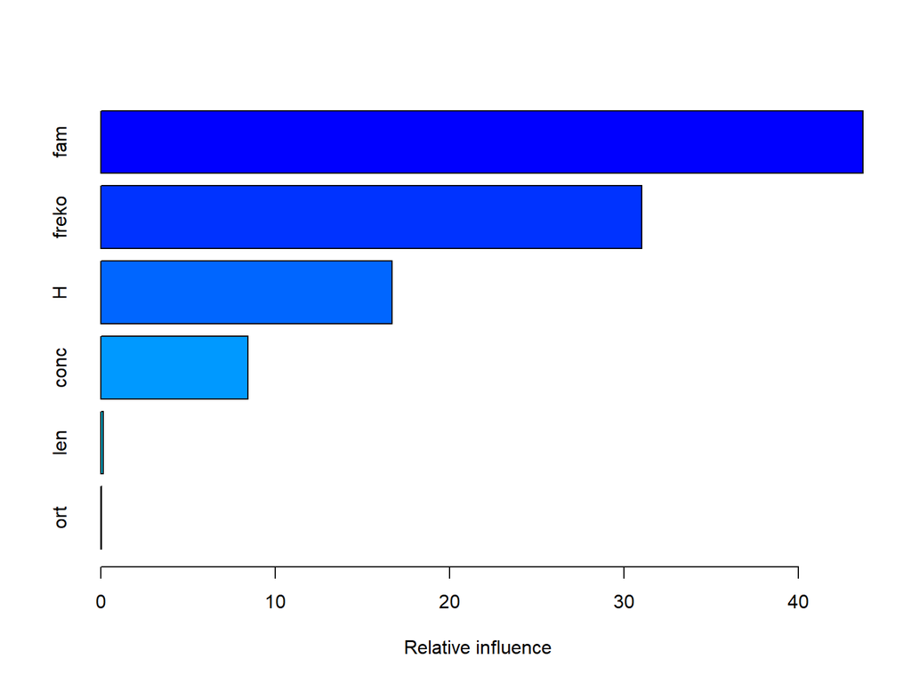

```r
gbm1
```

```
##         var     rel.inf
## fam     fam 43.70614443
## freko freko 31.01100280
## H         H 16.68962277
## conc   conc  8.43056028
## len     len  0.12665757
## ort     ort  0.03601215
```

## since in this analysis we want to show that H works over and above the control, already-known variables, i.e. we are not interested in the individual control variables themselves, we choose a different approach — we run a principal component analysis on the set of control variables

```r
dat.pca = prcomp(dat[,c("len", "ort","freko","fam", "conc")],
                 center = TRUE,
                 scale. = TRUE)

summary(dat.pca)
```

```
## Importance of components:
##                           PC1    PC2    PC3    PC4    PC5
## Standard deviation     1.3033 1.1086 1.0042 0.7678 0.6888
## Proportion of Variance 0.3397 0.2458 0.2017 0.1179 0.0949
## Cumulative Proportion  0.3397 0.5855 0.7872 0.9051 1.0000
```

## let’s plot the variance

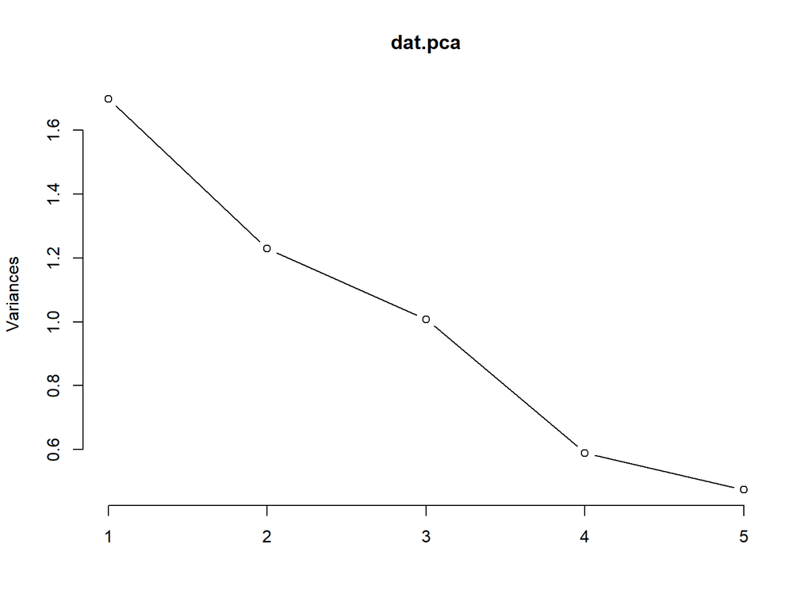

```r
plot(dat.pca, type = "l")
```

## let’s plot the percentage of explained variance

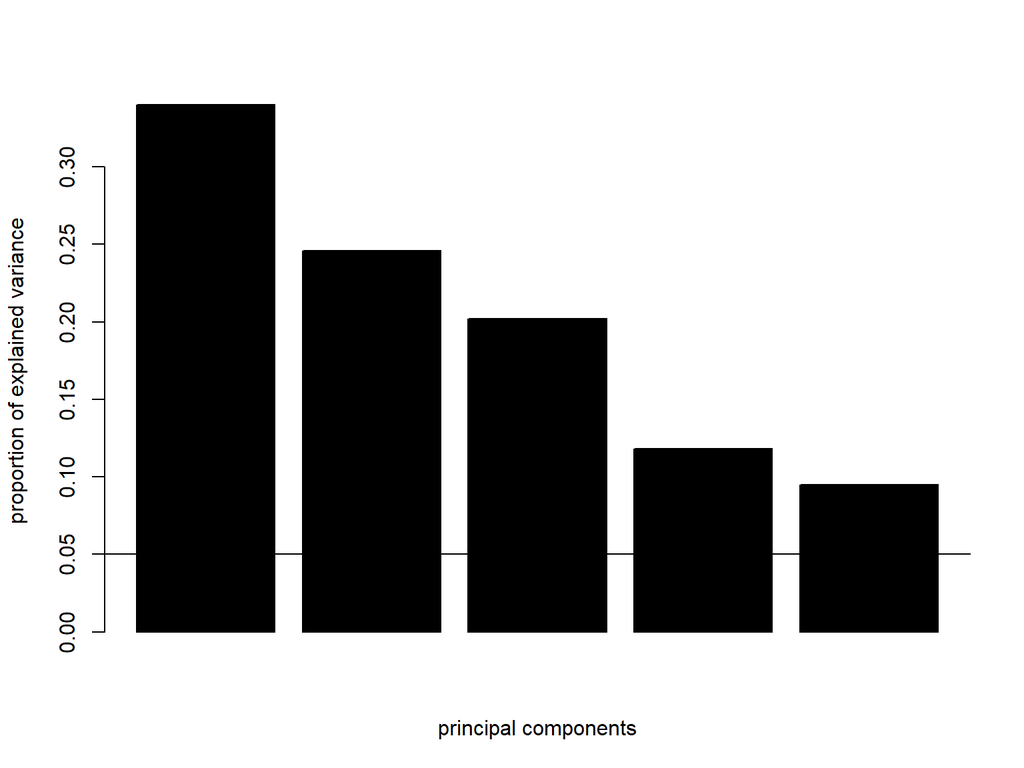

```r
props = round((dat.pca$sdev ^ 2 / sum(dat.pca$sdev ^ 2)), 3)
barplot(props, col = as.numeric (props > 0.05),
        xlab = "principal components",
        ylab = "proportion of explained variance")
abline (h = 0.05)
```

- all of them explain at least 5% of the variance, so we keep them all

## let’s look at the loadings

```r
dat.pca$rotation
```

```
##              PC1         PC2        PC3        PC4         PC5
## len    0.5342907 -0.28585236 -0.3155541 0.72968541  0.02840235
## ort   -0.4324293  0.51552262  0.2964444 0.65374684 -0.17882134
## freko -0.5365440 -0.04662957 -0.5645691 0.10646196  0.61633905
## fam   -0.4641173 -0.56113658 -0.2116484 0.05377134 -0.64964183
## conc  -0.1557370 -0.57920315  0.6700843 0.16108622  0.40658074
```

## let’s write out the coordinates of all words in the space of the new dimensions, creating new, non-collinear control variables

```r
dat$pc_1 = dat.pca$x[,1]
dat$pc_2 = dat.pca$x[,2]
dat$pc_3 = dat.pca$x[,3]
dat$pc_4 = dat.pca$x[,4]
dat$pc_5 = dat.pca$x[,5]
```

## Let’s examine collinearity in the new set

```r
collin.fnc(dat[,c("pc_1","pc_2","pc_3", "pc_4","pc_5", "H" )])$cnumber
```

```
## [1] 10.35495
```

- this is already more acceptable
- we see that H is weakly-to-moderately correlated with some of the components
- however, we’ll leave it as is, the Kappa coefficient is moderate, more acceptable
- and we want to show that H works over and above the control variables

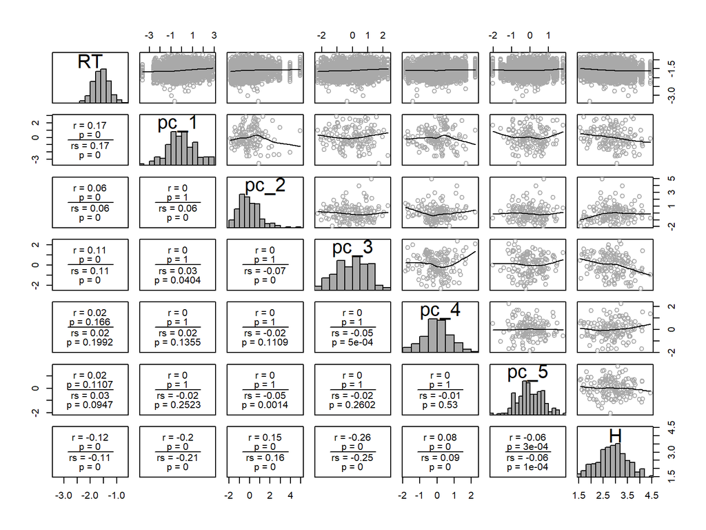

```r
pairscor.fnc(dat[,c("RT", "pc_1","pc_2","pc_3", "pc_4","pc_5", "H")], hist=TRUE, smooth=TRUE, cex.point=1, col.points="darkgrey")
```

## Let’s standardize the predictors

```r
dat$trial.z = scale(dat$Trial_order)
dat$freko.z = scale(dat$freko)
dat$len.z = scale(dat$len)
dat$fam.z = scale(dat$fam)
dat$conc.z = scale(dat$conc)
dat$ort.z = scale(dat$ort)
dat$N.z = scale(dat$N)
dat$T.z = scale(dat$T)
dat$H.z = scale(dat$H)
dat$PC1 = scale(dat$pc_1)
dat$PC2 = scale(dat$pc_2)
dat$PC3 = scale(dat$pc_3)
dat$PC4 = scale(dat$pc_4)
dat$PC5 = scale(dat$pc_5)
```

## let’s look at collinearity after scaling

```r
collin.fnc(dat[,c("PC1","PC2","PC3", "PC4","PC5", "H.z" )])$cnumber
```

```
## [1] 1.478941
```

## besides the Kappa coefficient, VIF (variance inflation factor) can also be used

- a VIF greater than 5 or 10 is considered large

```r
vif(lm(RT ~ len + ort + freko + fam + conc + H, data = dat))
```

```
##      len      ort    freko      fam     conc        H
## 1.239845 1.230137 1.346587 1.335932 1.191328 1.161114
```

## NOW WE CAN MOVE ON TO FITTING THE MODEL

- IMPORTANT NOTE
- STATISTICAL MODELING IS A COMBINATION OF SCIENCE AND SKILL
- YOU WILL NEVER FULLY MASTER THE TECHNIQUE
- NEW RECOMMENDATIONS ALWAYS KEEP APPEARING
- AS DO NEW “RULES” THAT SHOULD BE FOLLOWED
- AS WELL AS NEW WAYS OF DOING IT

## STRATEGY 1

- we start from the simplest model
- we add one parameter at a time
- we compare models
- if there’s no difference, the parameter isn’t justified
- if there is a difference, the parameter is justified, we keep it

## We start with basic models that have only the intercept among the fixed effects

- just Participants, and just words, as random effects,
- we compare these with a model that has both, to be sure of each one’s contribution

```r
lmer0a <- lmer(RT ~ 1 +
                 (1 |Participant),
               data=dat, REML=FALSE)
```

```r
lmer0b <- lmer(RT ~ 1 +
                 (1 |Word),
               data=dat, REML=FALSE)
```

```r
lmer0 <- lmer(RT ~ 1 +
                (1 | Participant) +
                (1 | Word),
              data=dat, REML=FALSE)
```

```r
anova(lmer0a, lmer0)
```

```
## Data: dat
## Models:
## lmer0a: RT ~ 1 + (1 | Participant)
## lmer0: RT ~ 1 + (1 | Participant) + (1 | Word)
##        npar    AIC    BIC  logLik -2*log(L)  Chisq Df Pr(>Chisq)
## lmer0a    3 783.86 802.93 -388.93    777.86
## lmer0     4 540.74 566.16 -266.37    532.74 245.13  1  < 2.2e-16 ***
## ---
## Signif. codes:  0 '***' 0.001 '**' 0.01 '*' 0.05 '.' 0.1 ' ' 1
```

```r
anova(lmer0b, lmer0)
```

```
## Data: dat
## Models:
## lmer0b: RT ~ 1 + (1 | Word)
## lmer0: RT ~ 1 + (1 | Participant) + (1 | Word)
##        npar     AIC     BIC  logLik -2*log(L)  Chisq Df Pr(>Chisq)
## lmer0b    3 1527.06 1546.13 -760.53   1521.06
## lmer0     4  540.74  566.16 -266.37    532.74 988.33  1  < 2.2e-16 ***
## ---
## Signif. codes:  0 '***' 0.001 '**' 0.01 '*' 0.05 '.' 0.1 ' ' 1
```

## We add trial order to the predictors

- first we visualize,
- then we build the model
- and check whether including that parameter is justified

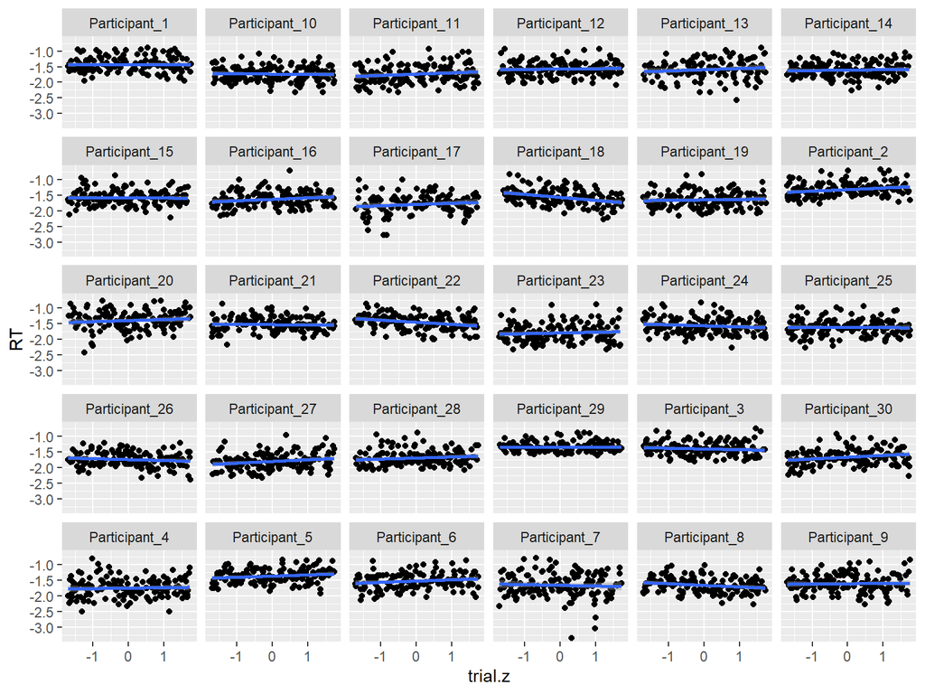

```r
ggplot(dat, aes(x=trial.z, y=RT)) +
  geom_point() +
  geom_smooth(method = "lm", se = TRUE) +
  facet_wrap(~Participant)
```

```r
lmer1a <- lmer(RT ~ trial.z +
                 (1 | Participant) +
                 (1 | Word),
               data=dat, REML=FALSE)
```

```r
anova(lmer0, lmer1a)
```

```
## Data: dat
## Models:
## lmer0: RT ~ 1 + (1 | Participant) + (1 | Word)
## lmer1a: RT ~ trial.z + (1 | Participant) + (1 | Word)
##        npar    AIC    BIC  logLik -2*log(L)  Chisq Df Pr(>Chisq)
## lmer0     4 540.74 566.16 -266.37    532.74
## lmer1a    5 534.03 565.81 -262.02    524.03 8.7045  1   0.003174 **
## ---
## Signif. codes:  0 '***' 0.001 '**' 0.01 '*' 0.05 '.' 0.1 ' ' 1
```

## We allow trial order to have a different effect for different Participants

```r
lmer1b <- lmer(RT ~ trial.z +
                 (1 + trial.z | Participant) +
                 (1 | Word),
               data=dat, REML=FALSE)
```

```r
anova(lmer1b, lmer1a)
```

```
## Data: dat
## Models:
## lmer1a: RT ~ trial.z + (1 | Participant) + (1 | Word)
## lmer1b: RT ~ trial.z + (1 + trial.z | Participant) + (1 | Word)
##        npar    AIC    BIC  logLik -2*log(L)  Chisq Df Pr(>Chisq)
## lmer1a    5 534.03 565.81 -262.02    524.03
## lmer1b    7 513.62 558.11 -249.81    499.62 24.412  2  5.002e-06 ***
## ---
## Signif. codes:  0 '***' 0.001 '**' 0.01 '*' 0.05 '.' 0.1 ' ' 1
```

## We check whether the correlation between the two parameters in the random interactions is justified

- by creating a model without the correlation
- and then comparing the fits

```r
lmer1bb <- lmer(RT ~ trial.z +
                  (1 + trial.z || Participant) +
                  (1 | Word),
                data=dat, REML=FALSE)
```

```r
anova(lmer1b, lmer1bb)
```

```
## Data: dat
## Models:
## lmer1bb: RT ~ trial.z + (1 + trial.z || Participant) + (1 | Word)
## lmer1b: RT ~ trial.z + (1 + trial.z | Participant) + (1 | Word)
##         npar    AIC    BIC  logLik -2*log(L)  Chisq Df Pr(>Chisq)
## lmer1bb    6 512.24 550.38 -250.12    500.24
## lmer1b     7 513.62 558.11 -249.81    499.62 0.6229  1       0.43
```

- the correlation is not justified

## Random interaction of trial order with words

```r
lmer1c <- lmer(RT ~ trial.z +
                 (1 + trial.z || Participant) +
                 (1 + trial.z | Word),
               data=dat, REML=FALSE)
```

```r
anova(lmer1bb, lmer1c)
```

```
## Data: dat
## Models:
## lmer1bb: RT ~ trial.z + (1 + trial.z || Participant) + (1 | Word)
## lmer1c: RT ~ trial.z + (1 + trial.z || Participant) + (1 + trial.z | Word)
##         npar    AIC    BIC  logLik -2*log(L)  Chisq Df Pr(>Chisq)
## lmer1bb    6 512.24 550.38 -250.12    500.24
## lmer1c     8 516.00 566.85 -250.00    500.00 0.2462  2     0.8842
```

- not justified, we go back to the previous model, lmer1bb

## Let’s add the next predictor

- and check whether including it in the model is justified
- i.e. whether it contributes to the explained variance

```r
lmer2 <- lmer(RT ~ trial.z + PC1 +
                (1 + trial.z || Participant) +
                (1 | Word),
              data=dat, REML=FALSE)
```

```r
anova(lmer1bb, lmer2)
```

```
## Data: dat
## Models:
## lmer1bb: RT ~ trial.z + (1 + trial.z || Participant) + (1 | Word)
## lmer2: RT ~ trial.z + PC1 + (1 + trial.z || Participant) + (1 | Word)
##         npar    AIC    BIC  logLik -2*log(L)  Chisq Df Pr(>Chisq)
## lmer1bb    6 512.24 550.38 -250.12    500.24
## lmer2      7 472.15 516.64 -229.07    458.15 42.094  1  8.697e-11 ***
## ---
## Signif. codes:  0 '***' 0.001 '**' 0.01 '*' 0.05 '.' 0.1 ' ' 1
```

## We add it to the random effects

```r
lmer2a <- lmer(RT ~ trial.z + PC1 +
                 (1 + PC1 | Participant) + (0 + trial.z | Participant) +
                 (1 | Word),
               data=dat, REML=FALSE)
```

```r
anova(lmer2, lmer2a)
```

```
## Data: dat
## Models:
## lmer2: RT ~ trial.z + PC1 + (1 + trial.z || Participant) + (1 | Word)
## lmer2a: RT ~ trial.z + PC1 + (1 + PC1 | Participant) + (0 + trial.z | Participant) + (1 | Word)
##        npar    AIC    BIC  logLik -2*log(L)  Chisq Df Pr(>Chisq)
## lmer2     7 472.15 516.64 -229.07    458.15
## lmer2a    9 476.10 533.31 -229.05    458.10 0.0449  2     0.9778
```

## Is the correlation among the random effects justified

```r
lmer2b <- lmer(RT ~ trial.z + PC1 +
                 (1 | Participant) + (0 + trial.z | Participant) +
                 (0 + PC1 | Participant) +
                 (1 | Word),
               data=dat, REML=FALSE)
```

```r
anova(lmer2a, lmer2b)
```

```
## Data: dat
## Models:
## lmer2b: RT ~ trial.z + PC1 + (1 | Participant) + (0 + trial.z | Participant) + (0 + PC1 | Participant) + (1 | Word)
## lmer2a: RT ~ trial.z + PC1 + (1 + PC1 | Participant) + (0 + trial.z | Participant) + (1 | Word)
##        npar    AIC    BIC  logLik -2*log(L)  Chisq Df Pr(>Chisq)
## lmer2b    8 474.15 525.00 -229.07    458.15
## lmer2a    9 476.10 533.31 -229.05    458.10 0.0449  1     0.8322
```

- not justified

## We test it for non-linearity

```r
lmer2c <- lmer(RT ~ trial.z + poly(PC1,2) +
                 (1 | Participant) + (0 + trial.z | Participant) +
                 (0 + PC1 | Participant) +
                 (1 | Word),
               data=dat, REML=FALSE)
```

```r
anova(lmer2b, lmer2c)
```

```
## Data: dat
## Models:
## lmer2b: RT ~ trial.z + PC1 + (1 | Participant) + (0 + trial.z | Participant) + (0 + PC1 | Participant) + (1 | Word)
## lmer2c: RT ~ trial.z + poly(PC1, 2) + (1 | Participant) + (0 + trial.z | Participant) + (0 + PC1 | Participant) + (1 | Word)
##        npar    AIC    BIC  logLik -2*log(L)  Chisq Df Pr(>Chisq)
## lmer2b    8 474.15 525.00 -229.07    458.15
## lmer2c    9 474.29 531.49 -228.14    456.29 1.8635  1     0.1722
```

## And so on for every predictor, building up the model

- and checking whether the added complication is justified by the data
- if we get into a zone where convergence is no longer possible
- we simplify the random effects structure
- in order to test the fixed effects
- and once we’ve built the final fixed-effects structure
- we repeat the testing with the more complex random-effects structure added back in

## Now, for the sake of illustration, let’s go ahead and add H

```r
lmer3a <- lmer(RT ~ trial.z + PC1 + H.z +
                 (1 | Participant) + (0 + trial.z | Participant) +
                 (0 + PC1 | Participant) +
                 (1 | Word),
               data=dat, REML=FALSE)
```

```r
anova(lmer2b, lmer3a)
```

```
## Data: dat
## Models:
## lmer2b: RT ~ trial.z + PC1 + (1 | Participant) + (0 + trial.z | Participant) + (0 + PC1 | Participant) + (1 | Word)
## lmer3a: RT ~ trial.z + PC1 + H.z + (1 | Participant) + (0 + trial.z | Participant) + (0 + PC1 | Participant) + (1 | Word)
##        npar    AIC    BIC  logLik -2*log(L)  Chisq Df Pr(>Chisq)
## lmer2b    8 474.15 525.00 -229.07    458.15
## lmer3a    9 460.12 517.32 -221.06    442.12 16.034  1  6.221e-05 ***
## ---
## Signif. codes:  0 '***' 0.001 '**' 0.01 '*' 0.05 '.' 0.1 ' ' 1
```

## We add it to the random effects

```r
lmer3b <- lmer(RT ~ trial.z + PC1 + H.z +
                 (1 + H.z| Participant) + (0 + trial.z | Participant) +
                 (0 + PC1 | Participant) +
                 (1 | Word),
               data=dat, REML=FALSE)
```

```r
anova(lmer3a, lmer3b)
```

```
## Data: dat
## Models:
## lmer3a: RT ~ trial.z + PC1 + H.z + (1 | Participant) + (0 + trial.z | Participant) + (0 + PC1 | Participant) + (1 | Word)
## lmer3b: RT ~ trial.z + PC1 + H.z + (1 + H.z | Participant) + (0 + trial.z | Participant) + (0 + PC1 | Participant) + (1 | Word)
##        npar    AIC    BIC  logLik -2*log(L)  Chisq Df Pr(>Chisq)
## lmer3a    9 460.12 517.32 -221.06    442.12
## lmer3b   11 461.58 531.50 -219.79    439.58 2.5353  2     0.2815
```

## Is the correlation justified

```r
lmer3c <- lmer(RT ~ trial.z + PC1 + H.z +
                 (1 | Participant) + (0 + trial.z | Participant) +
                 (0 + PC1 | Participant) + (0 + H.z | Participant) +
                 (1 | Word),
               data=dat, REML=FALSE)
```

```r
anova(lmer3b, lmer3c)
```

```
## Data: dat
## Models:
## lmer3c: RT ~ trial.z + PC1 + H.z + (1 | Participant) + (0 + trial.z | Participant) + (0 + PC1 | Participant) + (0 + H.z | Participant) + (1 | Word)
## lmer3b: RT ~ trial.z + PC1 + H.z + (1 + H.z | Participant) + (0 + trial.z | Participant) + (0 + PC1 | Participant) + (1 | Word)
##        npar    AIC    BIC  logLik -2*log(L)  Chisq Df Pr(>Chisq)
## lmer3c   10 462.12 525.68 -221.06    442.12
## lmer3b   11 461.58 531.50 -219.79    439.58 2.5353  1     0.1113
```

- no, but we’re keeping it for now, since this is our key predictor

## We test it for non-linearity

```r
lmer3d <- lmer(RT ~ trial.z + PC1 + poly(H, 2) +
                 (1 + H.z| Participant) + (0 + trial.z | Participant) +
                 (0 + PC1 | Participant) +
                 (1 | Word),
               data=dat, REML=FALSE)
```

```r
anova(lmer3c, lmer3d)
```

```
## Data: dat
## Models:
## lmer3c: RT ~ trial.z + PC1 + H.z + (1 | Participant) + (0 + trial.z | Participant) + (0 + PC1 | Participant) + (0 + H.z | Participant) + (1 | Word)
## lmer3d: RT ~ trial.z + PC1 + poly(H, 2) + (1 + H.z | Participant) + (0 + trial.z | Participant) + (0 + PC1 | Participant) + (1 | Word)
##        npar    AIC    BIC  logLik -2*log(L)  Chisq Df Pr(>Chisq)
## lmer3c   10 462.12 525.68 -221.06    442.12
## lmer3d   12 460.56 536.84 -218.28    436.56 5.5534  2    0.06224 .
## ---
## Signif. codes:  0 '***' 0.001 '**' 0.01 '*' 0.05 '.' 0.1 ' ' 1
```

- it is not non-linear

## THE MODEL HAS ALREADY REPORTED CONVERGENCE PROBLEMS

- THIS MEANS WE HAVE ALREADY OVERLOADED IT WITH RANDOM EFFECTS…
- AND WE’VE ONLY JUST BEGUN

## We test the interaction with fixed predictors

```r
lmer3e <- lmer(RT ~ trial.z * H.z + PC1 +
                 (1 + H.z| Participant) + (0 + trial.z | Participant) +
                 (0 + PC1 | Participant) +
                 (1 | Word),
               data=dat, REML=FALSE)
```

```r
anova(lmer3c, lmer3e)
```

```
## Data: dat
## Models:
## lmer3c: RT ~ trial.z + PC1 + H.z + (1 | Participant) + (0 + trial.z | Participant) + (0 + PC1 | Participant) + (0 + H.z | Participant) + (1 | Word)
## lmer3e: RT ~ trial.z * H.z + PC1 + (1 + H.z | Participant) + (0 + trial.z | Participant) + (0 + PC1 | Participant) + (1 | Word)
##        npar    AIC    BIC  logLik -2*log(L)  Chisq Df Pr(>Chisq)
## lmer3c   10 462.12 525.68 -221.06    442.12
## lmer3e   12 461.94 538.21 -218.97    437.94 4.1768  2     0.1239
```

- this interaction is not justified

```r
lmer3f <- lmer(RT ~ trial.z + PC1 * H.z +
                 (1 + H.z| Participant) + (0 + trial.z | Participant) +
                 (0 + PC1 | Participant) +
                 (1 | Word),
               data=dat, REML=FALSE)
```

```r
anova(lmer3c, lmer3f)
```

```
## Data: dat
## Models:
## lmer3c: RT ~ trial.z + PC1 + H.z + (1 | Participant) + (0 + trial.z | Participant) + (0 + PC1 | Participant) + (0 + H.z | Participant) + (1 | Word)
## lmer3f: RT ~ trial.z + PC1 * H.z + (1 + H.z | Participant) + (0 + trial.z | Participant) + (0 + PC1 | Participant) + (1 | Word)
##        npar    AIC    BIC  logLik -2*log(L)  Chisq Df Pr(>Chisq)
## lmer3c   10 462.12 525.68 -221.06    442.12
## lmer3f   12 455.78 532.06 -215.89    431.78 10.333  2   0.005705 **
## ---
## Signif. codes:  0 '***' 0.001 '**' 0.01 '*' 0.05 '.' 0.1 ' ' 1
```

- this interaction is justified; for now, lmer3f is the best model

## Only once we’ve shown that a predictor contributes to the explained variance are we allowed to look at whether the coefficient is statistically significant

```r
summary(lmer3f)
```

```
## Linear mixed model fit by maximum likelihood . t-tests use Satterthwaite's
##   method [lmerModLmerTest]
## Formula: RT ~ trial.z + PC1 * H.z + (1 + H.z | Participant) + (0 + trial.z |
##     Participant) + (0 + PC1 | Participant) + (1 | Word)
##    Data: dat
##
##       AIC       BIC    logLik -2*log(L)  df.resid
##     455.8     532.1    -215.9     431.8      4245
##
## Scaled residuals:
##     Min      1Q  Median      3Q     Max
## -6.5350 -0.6396 -0.0396  0.6216  3.9284
##
## Random effects:
##  Groups        Name        Variance  Std.Dev.  Corr
##  Word          (Intercept) 3.897e-03 6.243e-02
##  Participant   PC1         2.300e-11 4.796e-06
##  Participant.1 trial.z     8.311e-04 2.883e-02
##  Participant.2 (Intercept) 1.817e-02 1.348e-01
##                H.z         3.717e-05 6.096e-03 1.00
##  Residual                  6.040e-02 2.458e-01
## Number of obs: 4257, groups:  Word, 147; Participant, 30
##
## Fixed effects:
##               Estimate Std. Error         df t value Pr(>|t|)
## (Intercept)  -1.594415   0.025461  32.782523 -62.622  < 2e-16 ***
## trial.z       0.012192   0.007072  39.812691   1.724  0.09246 .
## PC1           0.045512   0.006587 141.907204   6.909 1.52e-10 ***
## H.z          -0.026690   0.006609 138.278776  -4.038 8.88e-05 ***
## PC1:H.z      -0.019855   0.007007 142.043777  -2.834  0.00527 **
## ---
## Signif. codes:  0 '***' 0.001 '**' 0.01 '*' 0.05 '.' 0.1 ' ' 1
##
## Correlation of Fixed Effects:
##         (Intr) tril.z PC1    H.z
## trial.z  0.001
## PC1     -0.009  0.000
## H.z      0.161 -0.023  0.202
## PC1:H.z  0.056  0.020 -0.141 -0.046
## optimizer (nloptwrap) convergence code: 0 (OK)
## boundary (singular) fit: see help('isSingular')
```

## STRATEGY 2

- we start from the most complex, meaningful model
- we remove one parameter at a time
- we compare models
- if there’s no difference, that parameter isn’t justified
- if there is a difference, that parameter is justified, we keep it

```r
lmerXa <- lmer(RT ~ trial.z * PC1 * H.z +
                 (1 + trial.z * PC1 * H.z|Participant) +
                 (1 + trial.z |Word),
               data=dat, REML=FALSE)
```

- first let’s try to simplify the random-effects structure

```r
summary(rePCA(lmerXa))
```

```
## $Word
## Importance of components:
##                          [,1]      [,2]
## Standard deviation     0.2592 1.499e-05
## Proportion of Variance 1.0000 0.000e+00
## Cumulative Proportion  1.0000 1.000e+00
##
## $Participant
## Importance of components:
##                          [,1]    [,2]    [,3]    [,4]      [,5]      [,6]
## Standard deviation     0.5560 0.12429 0.05497 0.03930 0.0007787 0.0001001
## Proportion of Variance 0.9392 0.04692 0.00918 0.00469 0.0000000 0.0000000
## Cumulative Proportion  0.9392 0.98613 0.99531 1.00000 1.0000000 1.0000000
##                             [,7]      [,8]
## Standard deviation     4.298e-06 2.813e-21
## Proportion of Variance 0.000e+00 0.000e+00
## Cumulative Proportion  1.000e+00 1.000e+00
```

- this will often fail to converge

## Because of that it’s convenient to go back to a simpler random-effects structure to make things easier

- But only for exploratory purposes (to save some time)
  - for the final analyses, we must apply the strategy of starting with the maximum model structure (see previous session)

```r
lmerX <- lmer(RT ~ trial.z * PC1 * H.z +
                 (1 |Participant) +
                 (1 |Word),
               data=dat, REML=FALSE)
```

## Let’s remove one parameter, the triple interaction, and build a new model

```r
lmerX1 <- lmer(RT ~ trial.z * PC1 +
                    trial.z * H.z +
                    PC1 * H.z +
                    (1 |Participant) +
                    (1 |Word),
                    data=dat, REML=FALSE)
```

```r
anova(lmerX1, lmerX)
```

```
## Data: dat
## Models:
## lmerX1: RT ~ trial.z * PC1 + trial.z * H.z + PC1 * H.z + (1 | Participant) + (1 | Word)
## lmerX: RT ~ trial.z * PC1 * H.z + (1 | Participant) + (1 | Word)
##        npar    AIC    BIC  logLik -2*log(L)  Chisq Df Pr(>Chisq)
## lmerX1   10 477.58 541.14 -228.79    457.58
## lmerX    11 479.56 549.48 -228.78    457.56 0.0166  1     0.8974
```

- the triple interaction is not justified

## Now let’s remove one two-way interaction at a time

```r
lmerX2 <- lmer(RT ~ trial.z * PC1 +
                 trial.z * H.z +
                 (1 |Participant) +
                 (1 |Word),
               data=dat, REML=FALSE)
```

```r
anova(lmerX1, lmerX2)
```

```
## Data: dat
## Models:
## lmerX2: RT ~ trial.z * PC1 + trial.z * H.z + (1 | Participant) + (1 | Word)
## lmerX1: RT ~ trial.z * PC1 + trial.z * H.z + PC1 * H.z + (1 | Participant) + (1 | Word)
##        npar    AIC    BIC  logLik -2*log(L) Chisq Df Pr(>Chisq)
## lmerX2    9 482.88 540.08 -232.44    464.88
## lmerX1   10 477.58 541.14 -228.79    457.58 7.297  1   0.006907 **
## ---
## Signif. codes:  0 '***' 0.001 '**' 0.01 '*' 0.05 '.' 0.1 ' ' 1
```

- the PC1 by H.z interaction is justified

```r
lmerX3 <- lmer(RT ~ trial.z * PC1 +
                 PC1 * H.z +
                 (1 |Participant) +
                 (1 |Word),
               data=dat, REML=FALSE)
```

```r
anova(lmerX1, lmerX3)
```

```
## Data: dat
## Models:
## lmerX3: RT ~ trial.z * PC1 + PC1 * H.z + (1 | Participant) + (1 | Word)
## lmerX1: RT ~ trial.z * PC1 + trial.z * H.z + PC1 * H.z + (1 | Participant) + (1 | Word)
##        npar    AIC    BIC  logLik -2*log(L)  Chisq Df Pr(>Chisq)
## lmerX3    9 476.40 533.60 -229.20    458.40
## lmerX1   10 477.58 541.14 -228.79    457.58 0.8163  1     0.3663
```

- the trial.z by H.z interaction is not justified

```r
lmerX4 <- lmer(RT ~
                 trial.z * H.z +
                 PC1 * H.z +
                 (1 |Participant) +
                 (1 |Word),
               data=dat, REML=FALSE)
```

```r
anova(lmerX1, lmerX4)
```

```
## Data: dat
## Models:
## lmerX4: RT ~ trial.z * H.z + PC1 * H.z + (1 | Participant) + (1 | Word)
## lmerX1: RT ~ trial.z * PC1 + trial.z * H.z + PC1 * H.z + (1 | Participant) + (1 | Word)
##        npar    AIC    BIC  logLik -2*log(L)  Chisq Df Pr(>Chisq)
## lmerX4    9 475.68 532.89 -228.84    457.68
## lmerX1   10 477.58 541.14 -228.79    457.58 0.1011  1     0.7505
```

- the trial.z by PC1 interaction is not justified

## Based on these comparisons, we keep in the model only the parameters whose removal makes a difference

- we keep only the interaction that is justified

```r
lmerX5 <- lmer(RT ~ trial.z +
                 PC1 * H.z +
                 (1 |Participant) +
                 (1 |Word),
               data=dat, REML=FALSE)
```

```r
anova(lmerX1, lmerX5)
```

```
## Data: dat
## Models:
## lmerX5: RT ~ trial.z + PC1 * H.z + (1 | Participant) + (1 | Word)
## lmerX1: RT ~ trial.z * PC1 + trial.z * H.z + PC1 * H.z + (1 | Participant) + (1 | Word)
##        npar    AIC    BIC  logLik -2*log(L)  Chisq Df Pr(>Chisq)
## lmerX5    8 474.65 525.50 -229.32    458.65
## lmerX1   10 477.58 541.14 -228.79    457.58 1.0708  2     0.5854
```

- no difference, so the simpler model lmerX5 performs just as well as the more complex lmerX1

## Let’s check whether the remaining non-interaction terms are needed

- what about the main effect of trial.z

```r
lmerX6 <- lmer(RT ~
                 PC1 * H.z +
                 (1 |Participant) +
                 (1 |Word),
               data=dat, REML=FALSE)
```

```r
anova(lmerX5, lmerX6)
```

```
## Data: dat
## Models:
## lmerX6: RT ~ PC1 * H.z + (1 | Participant) + (1 | Word)
## lmerX5: RT ~ trial.z + PC1 * H.z + (1 | Participant) + (1 | Word)
##        npar    AIC    BIC  logLik -2*log(L)  Chisq Df Pr(>Chisq)
## lmerX6    7 480.78 525.27 -233.39    466.78
## lmerX5    8 474.65 525.50 -229.32    458.65 8.1299  1   0.004354 **
## ---
## Signif. codes:  0 '***' 0.001 '**' 0.01 '*' 0.05 '.' 0.1 ' ' 1
```

- it is justified
- lmerX5 is still the best model

## Now let’s bring back the random interactions

- IF THE MODEL WON’T CONVERGE, FIRST REMOVE THE CORRELATIONS BETWEEN RANDOM EFFECTS

```r
lmerY <- lmer(RT ~ trial.z +
                 PC1 * H.z +
                 (1 + trial.z + PC1 * H.z | Participant) +
                 (1 + trial.z | Word),
               data=dat, REML=FALSE)
```

```r
anova(lmerX6, lmerY)
```

```
## Data: dat
## Models:
## lmerX6: RT ~ PC1 * H.z + (1 | Participant) + (1 | Word)
## lmerY: RT ~ trial.z + PC1 * H.z + (1 + trial.z + PC1 * H.z | Participant) + (1 + trial.z | Word)
##        npar    AIC    BIC  logLik -2*log(L)  Chisq Df Pr(>Chisq)
## lmerX6    7 480.78 525.27 -233.39    466.78
## lmerY    24 472.94 625.49 -212.47    424.94 41.837 17   0.000708 ***
## ---
## Signif. codes:  0 '***' 0.001 '**' 0.01 '*' 0.05 '.' 0.1 ' ' 1
```

- all these random interactions contribute jointly
- but
- let’s check whether all the random effects are justified

```r
summary(rePCA(lmerY))
```

```
## $Word
## Importance of components:
##                          [,1] [,2]
## Standard deviation     0.2547    0
## Proportion of Variance 1.0000    0
## Cumulative Proportion  1.0000    1
##
## $Participant
## Importance of components:
##                          [,1]    [,2]    [,3]      [,4] [,5]
## Standard deviation     0.5542 0.12176 0.04129 5.064e-05    0
## Proportion of Variance 0.9489 0.04581 0.00527 0.000e+00    0
## Cumulative Proportion  0.9489 0.99473 1.00000 1.000e+00    1
```

## LET’S DISPLAY THE COEFFICIENTS TO DETECT THE COMPONENTS WITH THE SMALLEST VARIANCE, WHICH WE WILL REMOVE

```r
lmerY
```

```
## Linear mixed model fit by maximum likelihood  ['lmerModLmerTest']
## Formula: RT ~ trial.z + PC1 * H.z + (1 + trial.z + PC1 * H.z | Participant) +
##     (1 + trial.z | Word)
##    Data: dat
##       AIC       BIC    logLik -2*log(L)  df.resid
##  472.9428  625.4945 -212.4714  424.9428      4233
## Random effects:
##  Groups      Name        Std.Dev. Corr
##  Word        (Intercept) 0.062480
##              trial.z     0.001106 -1.00
##  Participant (Intercept) 0.135617
##              trial.z     0.028622 -0.19
##              PC1         0.006146  0.31 -0.19
##              H.z         0.010230  0.64 -0.42  0.90
##              PC1:H.z     0.011266  0.34 -0.88  0.63  0.78
##  Residual                0.245345
## Number of obs: 4257, groups:  Word, 147; Participant, 30
## Fixed Effects:
## (Intercept)      trial.z          PC1          H.z      PC1:H.z
##    -1.59453      0.01187      0.04540     -0.02673     -0.02003
## optimizer (nloptwrap) convergence code: 0 (OK) ; 0 optimizer warnings; 1 lme4 warnings
```

## Let’s compare the two models

```r
lmerY1 <- lmer(RT ~ trial.z +
                PC1 * H.z +
                (1 + trial.z + H.z | Participant) +
                (1 | Word),
              data=dat, REML=FALSE)
```

```r
anova(lmerY, lmerY1)
```

```
## Data: dat
## Models:
## lmerY1: RT ~ trial.z + PC1 * H.z + (1 + trial.z + H.z | Participant) + (1 | Word)
## lmerY: RT ~ trial.z + PC1 * H.z + (1 + trial.z + PC1 * H.z | Participant) + (1 + trial.z | Word)
##        npar    AIC    BIC  logLik -2*log(L)  Chisq Df Pr(>Chisq)
## lmerY1   13 456.79 539.43 -215.40    430.79
## lmerY    24 472.94 625.49 -212.47    424.94 5.8503 11     0.8832
```

- no difference between the two models
- so the added complexity was unnecessary
- the final model is lmerY1

## Only now are we allowed to look at the coefficients

```r
summary(lmerY1)
```

```
## Linear mixed model fit by maximum likelihood . t-tests use Satterthwaite's
##   method [lmerModLmerTest]
## Formula: RT ~ trial.z + PC1 * H.z + (1 + trial.z + H.z | Participant) +
##     (1 | Word)
##    Data: dat
##
##       AIC       BIC    logLik -2*log(L)  df.resid
##     456.8     539.4    -215.4     430.8      4244
##
## Scaled residuals:
##     Min      1Q  Median      3Q     Max
## -6.5308 -0.6393 -0.0382  0.6168  3.9430
##
## Random effects:
##  Groups      Name        Variance  Std.Dev. Corr
##  Word        (Intercept) 3.909e-03 0.062519
##  Participant (Intercept) 1.816e-02 0.134756
##              trial.z     8.388e-04 0.028961 -0.18
##              H.z         4.565e-05 0.006756  0.92 -0.56
##  Residual                6.039e-02 0.245748
## Number of obs: 4257, groups:  Word, 147; Participant, 30
##
## Fixed effects:
##               Estimate Std. Error         df t value Pr(>|t|)
## (Intercept)  -1.594398   0.025459  32.812453 -62.627  < 2e-16 ***
## trial.z       0.012305   0.007091  39.738098   1.735  0.09042 .
## PC1           0.045487   0.006593 141.823894   6.899 1.60e-10 ***
## H.z          -0.026706   0.006636 135.833803  -4.024 9.45e-05 ***
## PC1:H.z      -0.019841   0.007013 141.961196  -2.829  0.00534 **
## ---
## Signif. codes:  0 '***' 0.001 '**' 0.01 '*' 0.05 '.' 0.1 ' ' 1
##
## Correlation of Fixed Effects:
##         (Intr) tril.z PC1    H.z
## trial.z -0.128
## PC1     -0.009  0.000
## H.z      0.163 -0.100  0.201
## PC1:H.z  0.056  0.020 -0.141 -0.046
## optimizer (nloptwrap) convergence code: 0 (OK)
## boundary (singular) fit: see help('isSingular')
```

## We still need to check whether the effects are non-linear

## Finally, we move on to diagnostics

```r
confint(lmerY1, method="Wald")
```

```
##                    2.5 %       97.5 %
## .sig01                NA           NA
## .sig02                NA           NA
## .sig03                NA           NA
## .sig04                NA           NA
## .sig05                NA           NA
## .sig06                NA           NA
## .sig07                NA           NA
## .sigma                NA           NA
## (Intercept) -1.644296344 -1.544500345
## trial.z     -0.001592118  0.026202573
## PC1          0.032565012  0.058409958
## H.z         -0.039712462 -0.013698974
## PC1:H.z     -0.033587139 -0.006095546
```

- We see that our effects are always on the same side of zero
- except for the trial-order effect, which isn’t very reliable

## Now we will check whether any of the assumptions for applying a linear model have been violated:

- Let’s create a column with the predicted DV values:

```r
dat$RT.fitted = predict(lmerY1)
```

- Let’s create a column with the residuals:

```r
dat$RT.res = residuals(lmerY1)
```

- Let’s plot the correlation between the fitted values and the residuals
- To check whether there is homogeneity of variance
- This should look like a nice “egg”

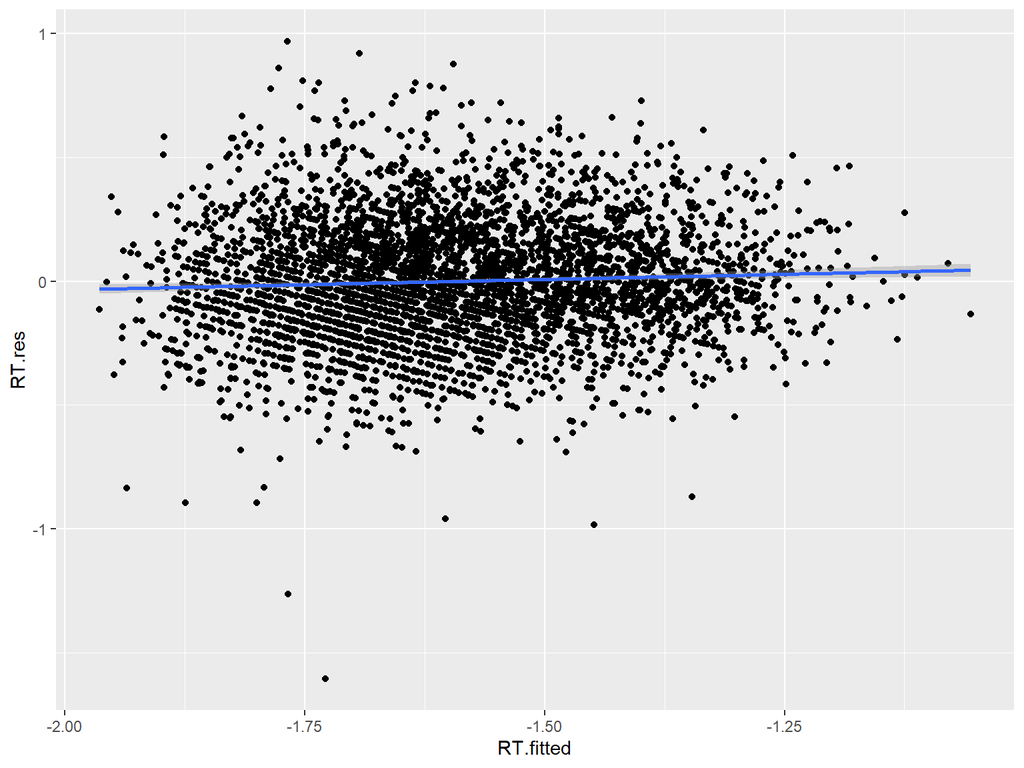

```r
ggplot(dat, aes(x=RT.fitted, y=RT.res)) +
  geom_point() +
  geom_smooth(method = "lm", se = TRUE)
```

## Let’s check whether the residuals are normally distributed

- This should be as close as possible to a straight line:

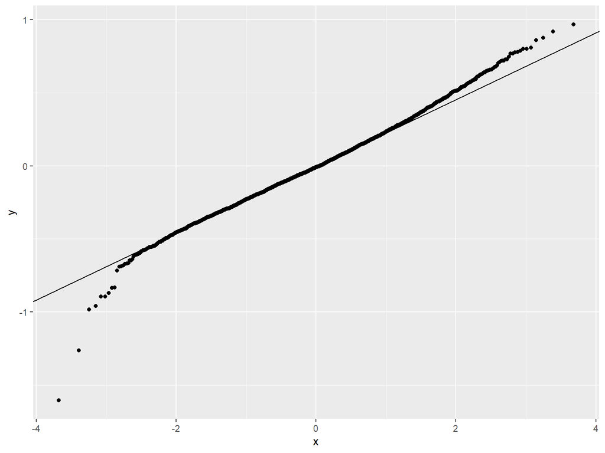

```r
ggplot(dat, aes(sample=RT.res)) +
  stat_qq() + stat_qq_line()
```

## The same thing can also be done like this:

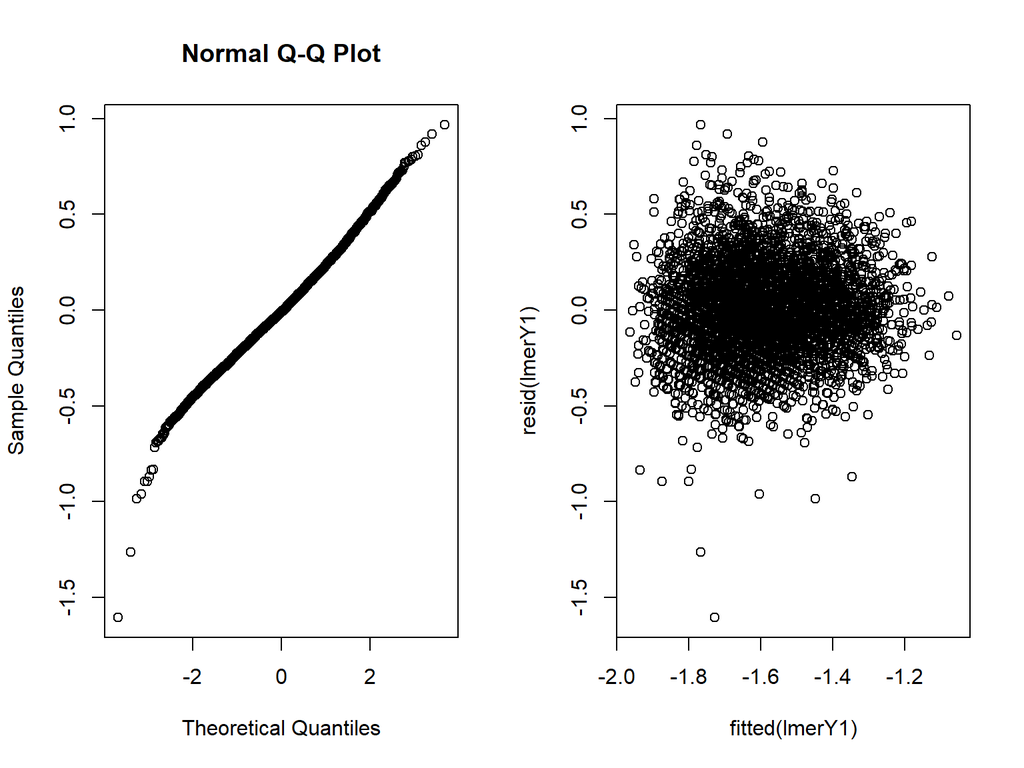

```r
par(mfcol=c(1,2))
qqnorm(resid(lmerY1))
plot(fitted(lmerY1), resid(lmerY1))
```

```r
par(mfcol=c(1,1))
```

## Now we’ll remove the points with large residuals

- And check whether they have too much influence on the model
- We refit the model on a subset of points whose residuals are within the range of +/-2.5 sigma

```r
lmerY1t <- lmer(RT ~ trial.z +
                 PC1 * H.z +
                 (1 + trial.z + H.z | Participant) +
                 (1 | Word),
                 data=dat,
                 subset=abs(scale(resid(lmerY1)))<2.5,
                 REML=FALSE)
```

- Let’s compare the coefficients from the cleaned and the original model
- there shouldn’t be drastic changes

```r
summary(lmerY1t)
```

```
## Linear mixed model fit by maximum likelihood . t-tests use Satterthwaite's
##   method [lmerModLmerTest]
## Formula: RT ~ trial.z + PC1 * H.z + (1 + trial.z + H.z | Participant) +
##     (1 | Word)
##    Data: dat
##  Subset: abs(scale(resid(lmerY1))) < 2.5
##
##       AIC       BIC    logLik -2*log(L)  df.resid
##    -215.7    -133.3     120.9    -241.7      4173
##
## Scaled residuals:
##      Min       1Q   Median       3Q      Max
## -2.64784 -0.67140 -0.04187  0.67367  2.68290
##
## Random effects:
##  Groups      Name        Variance  Std.Dev. Corr
##  Word        (Intercept) 3.775e-03 0.061439
##  Participant (Intercept) 1.881e-02 0.137162
##              trial.z     8.429e-04 0.029033 -0.22
##              H.z         3.022e-05 0.005497  0.90 -0.62
##  Residual                5.122e-02 0.226326
## Number of obs: 4186, groups:  Word, 147; Participant, 30
##
## Fixed effects:
##               Estimate Std. Error         df t value Pr(>|t|)
## (Intercept)  -1.597905   0.025826  32.616825 -61.872  < 2e-16 ***
## trial.z       0.011044   0.006923  39.503714   1.595  0.11863
## PC1           0.047998   0.006357 142.191523   7.550 4.80e-12 ***
## H.z          -0.025537   0.006363 139.012255  -4.013 9.74e-05 ***
## PC1:H.z      -0.021056   0.006758 141.969554  -3.116  0.00222 **
## ---
## Signif. codes:  0 '***' 0.001 '**' 0.01 '*' 0.05 '.' 0.1 ' ' 1
##
## Correlation of Fixed Effects:
##         (Intr) tril.z PC1    H.z
## trial.z -0.161
## PC1     -0.009  0.000
## H.z      0.137 -0.096  0.203
## PC1:H.z  0.053  0.019 -0.141 -0.046
## optimizer (nloptwrap) convergence code: 0 (OK)
## boundary (singular) fit: see help('isSingular')
```

## let’s repeat the diagnostics

- things should now look even better

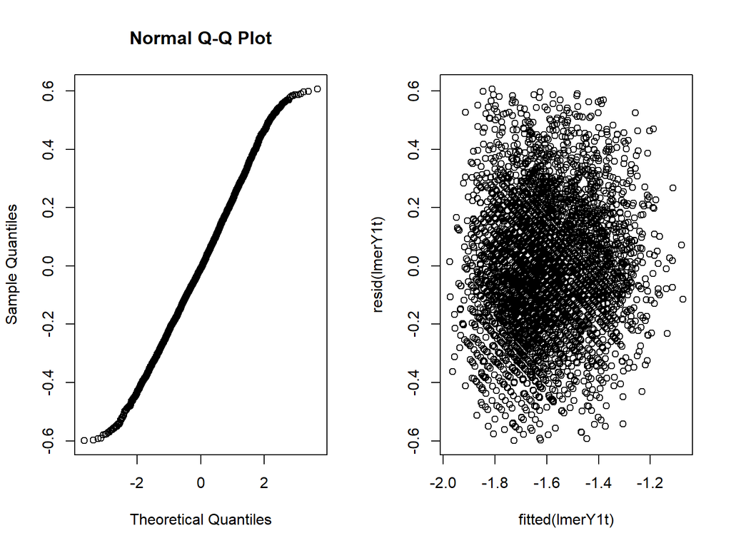

```r
par(mfcol=c(1,2))
qqnorm(resid(lmerY1t))
plot(fitted(lmerY1t), resid(lmerY1t))
```

```r
par(mfcol=c(1,1))
```

## let’s visualize the final effect of the main variable

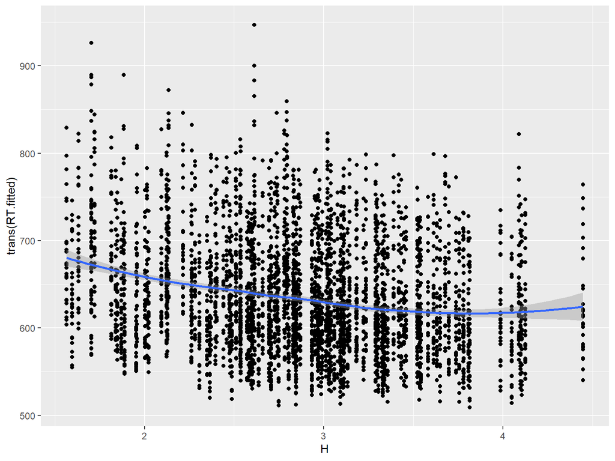

```r
ggplot(dat, aes(x=H, y=trans(RT.fitted))) +
  geom_point() +
  geom_smooth(method = "loess", se = TRUE)
```

```r
ggsave("H.lmerY1.jpg", width = 5, height = 5)
```

## let’s make a table for the paper

```r
sjPlot::tab_model(lmerY1t, show.se = TRUE, show.stat = TRUE, dv.labels = c("RT (ms)"))
```

|  | RT (ms) |  |  |  |  |
| --- | --- | --- | --- | --- | --- |
| Predictors | Estimates | std. Error | CI | Statistic | p |
| (Intercept) | -1.60 | 0.03 | -1.65 – -1.55 | -61.87 | **<0.001** |
| trial z | 0.01 | 0.01 | -0.00 – 0.02 | 1.60 | 0.111 |
| PC1 | 0.05 | 0.01 | 0.04 – 0.06 | 7.55 | **<0.001** |
| H z | -0.03 | 0.01 | -0.04 – -0.01 | -4.01 | **<0.001** |
| PC1 × H z | -0.02 | 0.01 | -0.03 – -0.01 | -3.12 | **0.002** |
| Random Effects |  |  |  |  |  |
| σ<sup>2</sup> | 0.05 |  |  |  |  |
| τ<sub>00</sub> <sub>Word</sub> | 0.00 |  |  |  |  |
| τ<sub>00</sub> <sub>Participant</sub> | 0.02 |  |  |  |  |
| τ<sub>11</sub> <sub>Participant.trial.z</sub> | 0.00 |  |  |  |  |
| τ<sub>11</sub> <sub>Participant.H.z</sub> | 0.00 |  |  |  |  |
| ρ<sub>01</sub> <sub>Participant.trial.z</sub> | -0.22 |  |  |  |  |
| ρ<sub>01</sub> <sub>Participant.H.z</sub> | 0.90 |  |  |  |  |
| N <sub>Participant</sub> | 30 |  |  |  |  |
| N <sub>Word</sub> | 147 |  |  |  |  |
| Observations | 4186 |  |  |  |  |
| Marginal R<sup>2</sup> / Conditional R<sup>2</sup> | 0.068 / NA |  |  |  |  |

## let’s visualize the coefficients

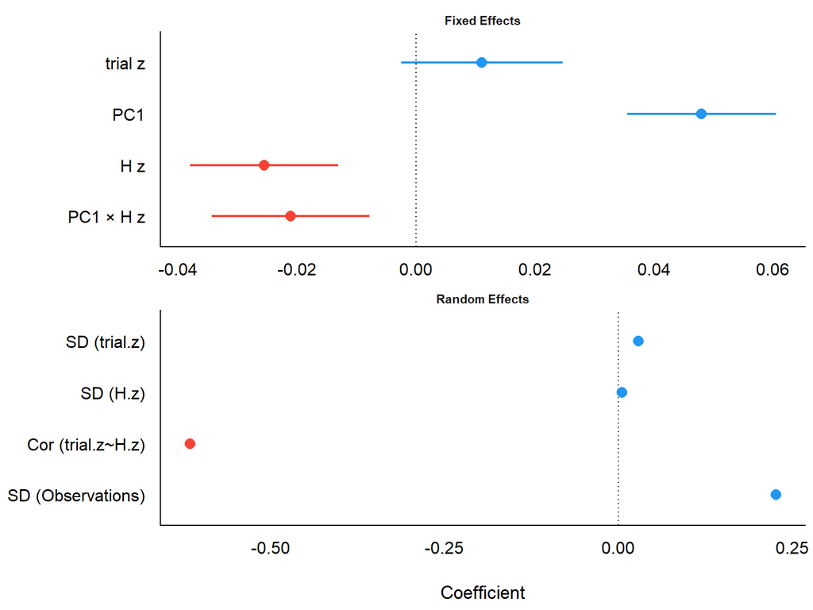

```r
plot(model_parameters(lmerY1t))
```